Briana Cervantes

11/11/2021

```r
testProbs2 <-
  data.frame(Outcome = df$recidivatedNumeric,
             Probs = predict(reg.noRace, df, type = "response"),
             Race = df$race2)



afrtestProbs<-subset(testProbs2, Race=='African-American')
afrtestProbs<-afrtestProbs%>%
  mutate(predOutcome  = as.factor(ifelse(afrtestProbs$Probs > 0.32 , 1, 0))) #.45

cauctestProbs<-subset(testProbs2, Race=='Caucasian')
cauctestProbs<-cauctestProbs%>%
  mutate(predOutcome  = as.factor(ifelse(cauctestProbs$Probs > 0.2 , 1, 0)))

othertestProbs<-subset(testProbs2, Race=='Other')
othertestProbs<- othertestProbs%>%
  mutate(predOutcome  = as.factor(ifelse(othertestProbs$Probs > 0.2 , 1, 0)))

testProbs2 <- afrtestProbs%>%rbind(cauctestProbs)%>%rbind(othertestProbs)
testProbs2$Outcome <- as.factor(testProbs2$Outcome)
testProbs2$predOutcome <- as.factor(testProbs2$predOutcome)

caret::confusionMatrix(testProbs2$predOutcome, testProbs2$Outcome,
                       positive = "1")


### OG 0.32,0.3,0.33
## second 0.45, 0.32, 0.36
## third 0.32, 0.20, 0.2
## fourth 0.32, 0.22, 0.24
```

## *Department of Prisons Calls for the use of Justice Based Algorithm in Job Reentry Program Updates*

#### Mayor Fake Name,

Leadership at the Department of Prisons urges you to consider our algorithm-based approach for the city’s new job reentry program. Our algorithm aims to identify the most at risk of recidivating to admit them into our job program and provide the support they need, to succeed after re-entering society.

While the city is hoping to revamp the existing job training program for formerly incarcerated persons (FIPs), the Department of Prisons understands that resources are limited. This fact alone ensures that some will suffer because they will not have the support that they need to reclaim their lives. Being without a panacea, the Department of Prisons urges the city to work as efficiently as possible. Our justice focused algorithm is the right tool for this job.

##### Table 1: Associated Costs

Table 1: Unit Costs and Benefits

| Result | Description | ProgramCost | SocialCost | WhoPays. | SocialBenefits | WhoBenefits. |
| --- | --- | --- | --- | --- | --- | --- |
| True Positive | We predicted recidivate and so allocated funds for this individual to participate in the job training program, and they recidivated | $13,000/per | $(21,831/FIP family + 51,000/IP^)*0.25 | Victims of crimes and FIPs and their families taxpayers, due the amount it coststo run prisons | $(21,831/FIP family+ 51,000/IP)*0.75 | The formerly incarcerated individual and their family, as well as society. |
| True Negative | We predicted no recidivate and so did not allocate funds for this individual, and they did not recidivate | $0 | $0 | NA | $(21,831/FIP family+ 51,000/IP) | The formerly incarcerated individual and their family, as well as society ,but no thanks to us |
| False Positive | we predicted recidivate and so allocated funds for this individual to participate in the job training program, and they did not recidivate | $13,000/per | $0 | Taxpayers^^ | $(21,831/FIP family+ 51,000/IP) | The formerly incarcerated individual and their family, as well as society. |
| False Negative | We predicted no recidivate and so did not allocate funds for this individual in, but they did recidivate | $0 | $21,831/FIP family + 51,000/IP | Victims of crimes, FIPs and their families | 0 | No one |

* ^ IP: Incarcerated Person  
† ^^ This will likely be unkown

Similarly, we have spent time considering the fairness of our model. While tools like this one can ease the decision-making process, we must be weary of disparate impacts that may result. Legally we are required to avoid even unintended consequences of our decisions that negatively impact different protected classes more than the majority. Morally, the city should already be motivated to do this as best it can for as many communities as it can, legally protected or otherwise. Thus, we first must acknowledge that the data informs this algorithm is biased, but with the right application it can still be useful in decision making. To avoid disparate impact, we have tailored a critical measure of our model: the decision threshold. The decision threshold is tailored to three different racial groups: African Americans, Caucasians, and a third group for all other racial demographics. In this way we have introduced nuance, and thus more control, into the outcome of our model. The bar graph below shows the difference in outcomes when a single threshold is used across racial groups and when the thresholds are tailored by race.

##### Figure 1: Tailored Threshold Results

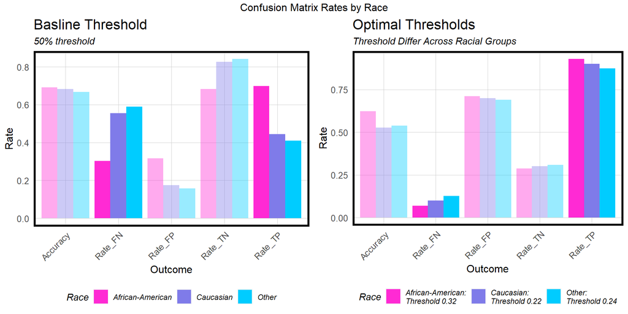

Since we are most concerned about accounting for all the FIPs that are at high risk of recidivating and not miscounting them as individuals not likely to recidivate, the two criteria used to find our decision threshold puts emphasis on optimizing True Positives and False Negatives (they are show in the bar graph in full opacity). A True Positive means that we have predicted they will recidivate, we allocate funding for them to participate in the jobs program, and based on our understanding, 25% of them do actually recidivate. A False Negative means that we predicted they would not recidivate and did not allocate funds for them, but they actually do recidivate, and we’ve missed them entirely. These are the two most undesirable outcomes.

While we should also avoid “wasting” funds by investing in FIPs that we predict will recidivate but don’t (False Positive), there is no way that we can ever truly know what that number is, and we can only approximate with further study. [^3] Additionally, some may argue that we should prioritize correctly identifying those that will not recidivate (True Negatives) to cut down costs, but we are more concerned with building an appropriately funded program that works.

##### Table 2: Estimated Costs

```r
cost_benefit_table1 <-
  testProbs2 %>%
  count(predOutcome, Outcome) %>%
  summarize(True_Positive = sum(n[predOutcome==1 & Outcome==1]),
            True_Negative = sum(n[predOutcome==0 & Outcome==0]),
            False_Positive = sum(n[predOutcome==1 & Outcome==0]),
            False_Negative = sum(n[predOutcome==0 & Outcome==1])) %>%
  gather(Variable, Count) %>%
  mutate(ProgramCost =
           ifelse(Variable == "True_Negative", Count * 0,
                  ifelse(Variable == "True_Positive",(13000 * Count),
                         ifelse(Variable == "False_Negative", 0 * Count,
                                ifelse(Variable == "False_Positive", (13000 * Count), 0))))) %>%
  mutate(SocialCost =
           ifelse(Variable == "True_Negative", Count * 0,
                  ifelse(Variable == "True_Positive",(((21831 + 51000)*0.25) * Count),
                         ifelse(Variable == "False_Negative", ((21831 + 51000) * Count),
                                ifelse(Variable == "False_Positive", 0 * Count, 0))))) %>%

    mutate(SocialBenefit =
           ifelse(Variable == "True_Negative", (Count * (21831 + 51000)),
                  ifelse(Variable == "True_Positive",(Count * ((21831 + 51000)*0.75)),
                         ifelse(Variable == "False_Negative", (0 * Count),
                                ifelse(Variable == "False_Positive", (21831 + 51000) * Count, 0))))) %>%

  bind_rows(., tibble(Variable= "Subtotal",
                      Count = 0,
                      ProgramCost = sum(.[["ProgramCost"]]),
                      SocialCost = sum(.[["SocialCost"]]),
                      SocialBenefit = sum(.[["SocialBenefit"]]))) %>%
  bind_rows(., tibble(Variable= "Total",
                      Count = 0,
                      ProgramCost = (.[[5,5]]-(.[[5,3]]+.[[5,4]])),
                      SocialCost = 0,
                      SocialBenefit = 0)) %>%
  mutate(ProgramCost= paste("$", format(round(ProgramCost, 8L), nsmall = 2L)),
         SocialCost = paste("$", format(round(SocialCost, 8L), nsmall = 2L)),
         SocialBenefit = paste("$", format(round(SocialBenefit, 8L), nsmall = 2L)))%>%
  bind_cols(data.frame(Description = c(
    "We correctly predicted recidivate",
    "We correctly predicted not recidivate",
    "We predicted recidivate but<br>they did not recidivate",
    "We predicted not recidivate but<br>they recidivated", " ", " ")))

cost_benefit_table1$Count<-replace(cost_benefit_table1$Count, cost_benefit_table1$Count <1, " ")
cost_benefit_table1[6,4]<-replace(cost_benefit_table1[6,4], ," ")
cost_benefit_table1[6,5]<-replace(cost_benefit_table1[6,5], ," ")

cb.table1<- kable(cost_benefit_table1,
      caption = "Table 2: Estimated Cost/Benefit Table",
      align = c('c','l', 'l', 'l', 'l', 'l'),
      format = 'html', escape = FALSE) %>%
  kable_styling(position = "center",
                font_size = 16)%>%
  kable_material(c("striped", "hover"), full_width=F)%>%
  column_spec(1, bold = T, border_right = T)%>%
  row_spec(c(2,4), background = "#f5c65d")%>%
  row_spec(4, extra_css = "border-bottom: 1px solid")%>%
  row_spec(6, bold =T, background = ifelse(as.numeric(gsub("\\$", " ", cost_benefit_table1[6, 3])) > 0, "#9cd9b9", "#e68e87"))%>%
  column_spec((1:6), extra_css = "vertical-align:middle;")
```

Table 2: Estimated Cost/Benefit Table

| Variable | Count | ProgramCost | SocialCost | SocialBenefit | Description |
| --- | --- | --- | --- | --- | --- |
| True_Positive | 2569 | $ 33397000.00 | $ 46775709.75 | $ 140327129.25 | We correctly predicted recidivate |
| True_Negative | 892 | $ 0.00 | $ 0.00 | $ 64965252.00 | We correctly predicted not recidivate |
| False_Positive | 2470 | $ 32110000.00 | $ 0.00 | $ 179892570.00 | We predicted recidivate but they did not recidivate |
| False_Negative | 231 | $ 0.00 | $ 16823961.00 | $ 0.00 | We predicted not recidivate but they recidivated |
| Subtotal |  | $ 65507000.00 | $ 63599670.75 | $ 385184951.25 |  |
| Total |  | $ 256078280.50 |  |  |  |

If we want to make use of this algorithm, it is imperative that it is both accurate and generalizable. Unfortunately, successfully meeting those two goals requires a tradeoff. In this case, we would like to apply this algorithm to many cohorts of reentering FIPs, and so we would hope our model can perform equally well across these different sets of data. That requires the algorithm to be flexible, but where it is flexible it may also be wrong. However, by structuring a program to call in the most vulnerable rather than cast them away, we can lessen the blow of being wrong. Additionally, our emphasis on keeping wrong predictions low, specifically when predicting FIPs will not recidivate, we have oriented this model to do the most social good. For these reasons and more we implore you to move forward with the Department of Prisons’ justice-based algorithm.

[^1]: The costs to Families are based on both the [*Who Pays?* Report](http://whopaysreport.org/executive-summary/) and investigative reporting done by the [Marshall Project](https://www.themarshallproject.org/2019/12/17/the-hidden-cost-of-incarceration) and they have been adjusted for inflation. The cost to FIP families can be broken out as: $15,878.80 for court fees, $3,786.56 for communication with FIP while incarcerated, and $2,163.75 for additional support of FIP by family members.
[^2]: This cost is based on the 2021 Annual cost per incarcerated person in Philadelpia, published by the [Vera Institute](https://www.vera.org/publications/what-jails-cost-cities/philadelphia-pa)
[^3]: Additional testing might include paired T-testing of the results and progress of the job program participants. The Social Cost associated with this is listed as “Taxpayers^^” in the cost benefit table.